# EDA Final project

## 2.2 annual and seasonal runoff

This table shows a plots of summary statitics of all stations over the period of all data collected, it shows the spread of the data. This could be important in being able to catagorise stations into specific subsets, such as differences in mean values, or the differences in the range, hence patterens could be deduced. Data with incorrect values from previous table has been removed.

```
##             id year      mean  max min        sd median
##     1: 6123100 1963  879.6548 2570 222  572.6777    695
##     2: 6123100 1964  568.8279 2400 125  564.6060    322
##     3: 6123100 1965  982.5589 3800 178  782.1658    720
##     4: 6123100 1966 1313.7288 4320 173 1078.9884   1070
##     5: 6123100 1967  764.7068 2740 180  605.8043    590
##    ---
## 20331: 6974150 2005  538.7260 1379 274  255.9645    411
## 20332: 6974150 2006  440.6493 1145 213  196.8941    402
## 20333: 6974150 2007  492.5945 1290 253  213.4821    442
## 20334: 6974150 2008  458.1339 1060 241  202.2230    376
## 20335: 6974150 2009  458.8603  901 243  161.7975    436
```

```
##             id year      mean  max min        sd median       COF      skew
##     1: 6123100 1963  879.6548 2570 222  572.6777    695 0.6510255 0.9673232
##     2: 6123100 1964  568.8279 2400 125  564.6060    322 0.9925779 1.3115051
##     3: 6123100 1965  982.5589 3800 178  782.1658    720 0.7960498 1.0070457
##     4: 6123100 1966 1313.7288 4320 173 1078.9884   1070 0.8213175 0.6776591
##     5: 6123100 1967  764.7068 2740 180  605.8043    590 0.7922046 0.8651648
##    ---
## 20331: 6974150 2005  538.7260 1379 274  255.9645    411 0.4751293 1.4969970
## 20332: 6974150 2006  440.6493 1145 213  196.8941    402 0.4468271 0.5888849
## 20333: 6974150 2007  492.5945 1290 253  213.4821    442 0.4333831 0.7109895
## 20334: 6974150 2008  458.1339 1060 241  202.2230    376 0.4414060 1.2184647
## 20335: 6974150 2009  458.8603  901 243  161.7975    436 0.3526072 0.4238684
##        meanmaxratio meanminratio
##     1:    0.3422781     3.962409
##     2:    0.2370116     4.550623
##     3:    0.2585681     5.519994
##     4:    0.3041039     7.593808
##     5:    0.2790901     4.248371
##    ---
## 20331:    0.3906643     1.966153
## 20332:    0.3848466     2.068776
## 20333:    0.3818562     1.947014
## 20334:    0.4322018     1.900970
## 20335:    0.5092789     1.888314
```

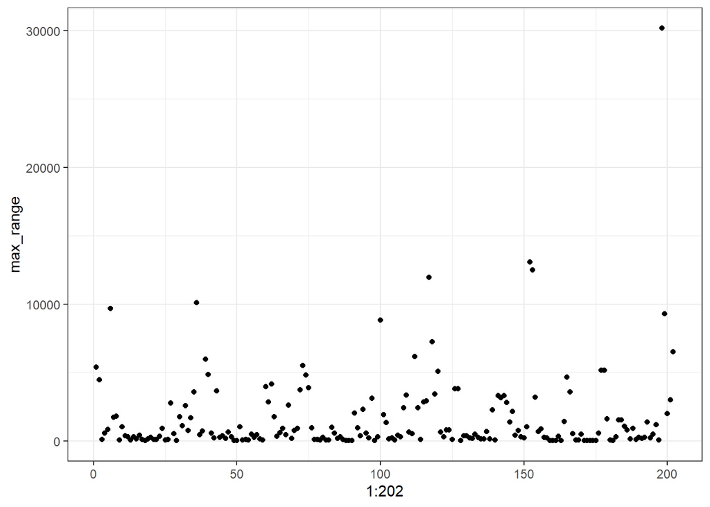

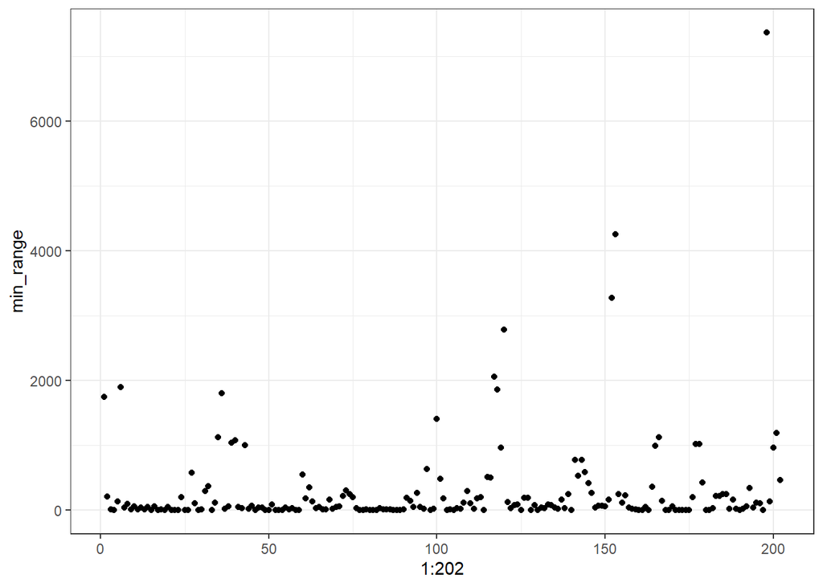

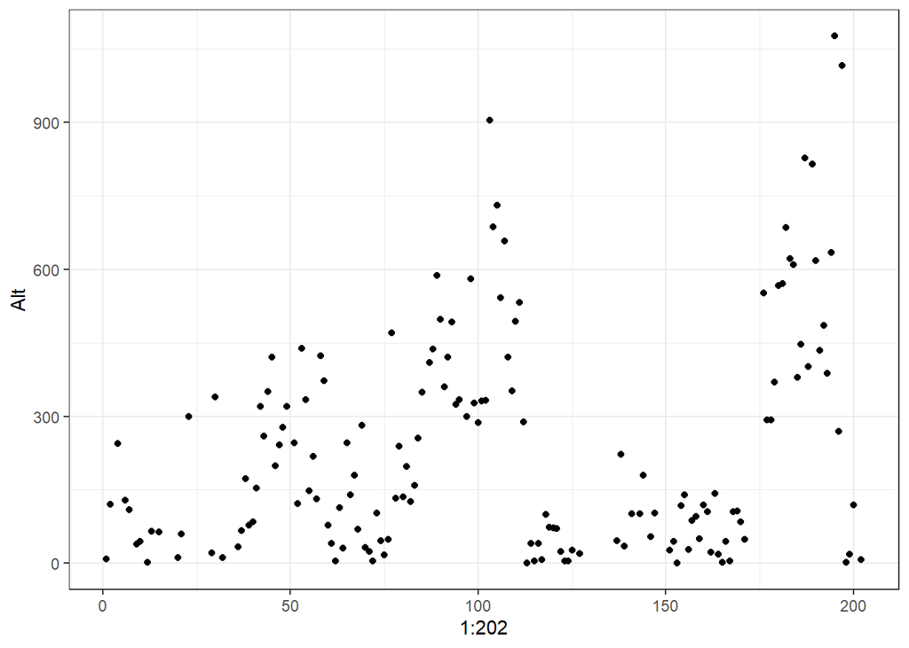